# Introduction to R

#### Save your plot as pdf:

```r
pdf("iris1.pdf") # open the pdf
plot(Petal.Length ~ Sepal.Length, data = iris, col = iris$Species, pch = 19)
legend(x = 4.5, y = 7, legend = levels(iris$Species), col = c(1:3), pch = 19)
dev.off() # close the pdf
```

#### Choose a different color:

- you have so many different colors in R to generate beautiful plots
- check online, e.g. http://www.stat.columbia.edu/~tzheng/files/Rcolor.pdf

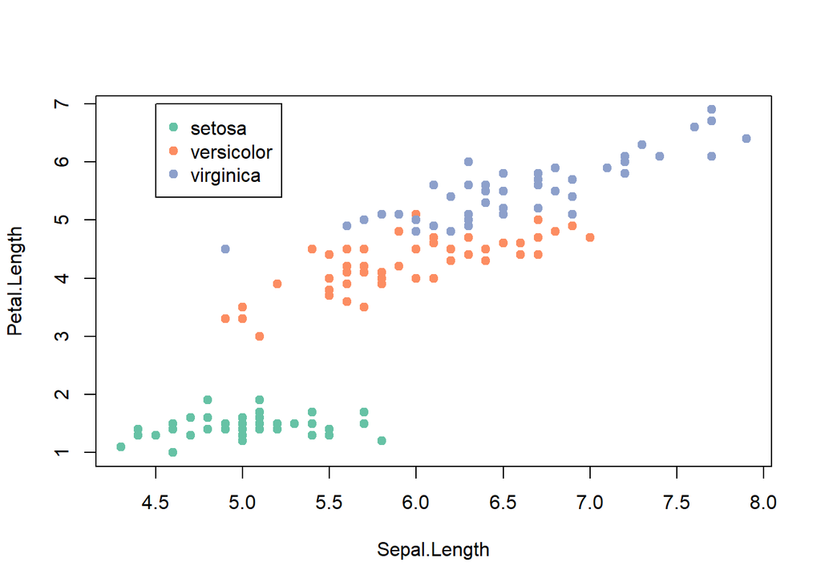

```r
library(RColorBrewer)
#display.brewer.all(n=3)
plot(Petal.Length ~ Sepal.Length, data = iris, col=brewer.pal(3, "Set2")[iris$Species], pch = 19)
legend(x=4.5, y=7, legend=levels(iris$Species), col=brewer.pal(3, "Set2"), pch=19)
```

#### ggplot2

- ggplot2 is a very convenient tool to create graphics
- you start with ggplot()
- supply a dataset (iris) and aesthetic mapping (with aes())
- add layers (like a boxplot + a scatter plot + the statistical analysis…)

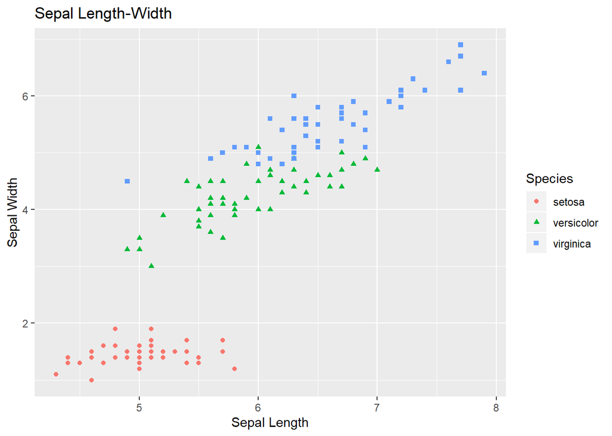

```r
library(ggplot2)
library(ggsignif)
scatter <- ggplot(data=iris, aes(x = Sepal.Length, y = Petal.Length))
scatter + geom_point(aes(color=Species, shape=Species)) +
  xlab("Sepal Length") +  ylab("Sepal Width") +
  ggtitle("Sepal Length-Width")
```

#### Include a third feature:

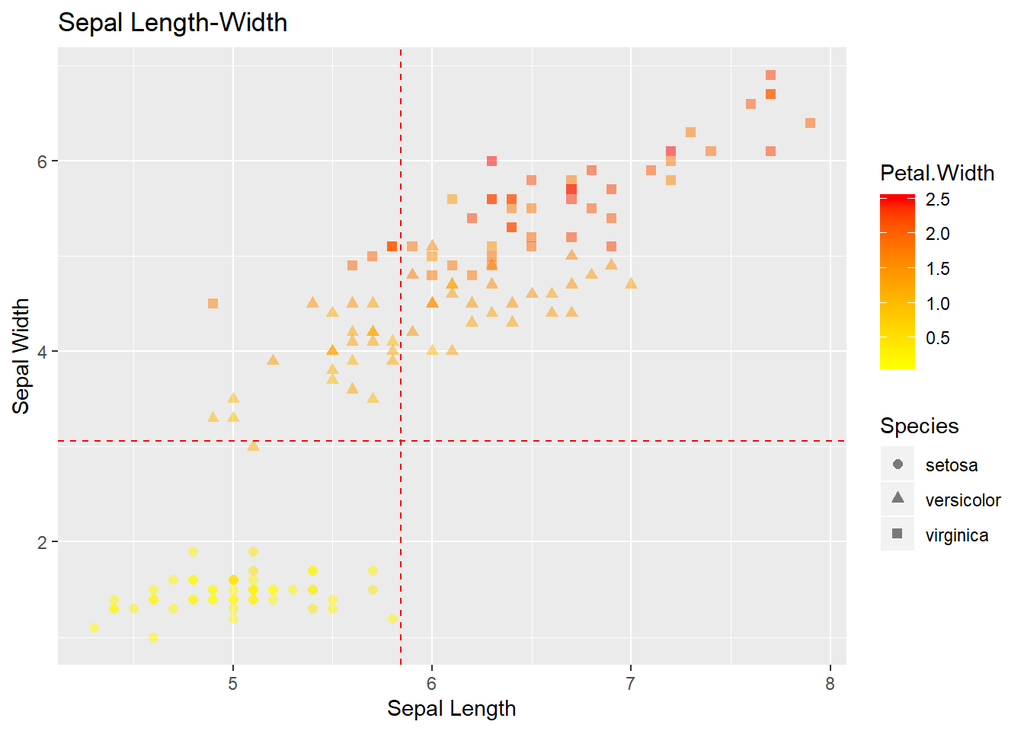

```r
scatter + geom_point(aes(color = Petal.Width, shape = Species), size = 2, alpha = I(1/2)) +
  geom_vline(aes(xintercept = mean(Sepal.Length)), color = "red", linetype = "dashed") +
  geom_hline(aes(yintercept = mean(Sepal.Width)), color = "red", linetype = "dashed") +
  scale_color_gradient(low = "yellow", high = "red") +
  xlab("Sepal Length") +  ylab("Sepal Width") +
  ggtitle("Sepal Length-Width")
```

–> The horizontal and vertical lines mark the mean of sepal.width and sepal.length, respectively  
–> Different color for the different levels of petal.width  
–> Different shape for every species

### Boxplot

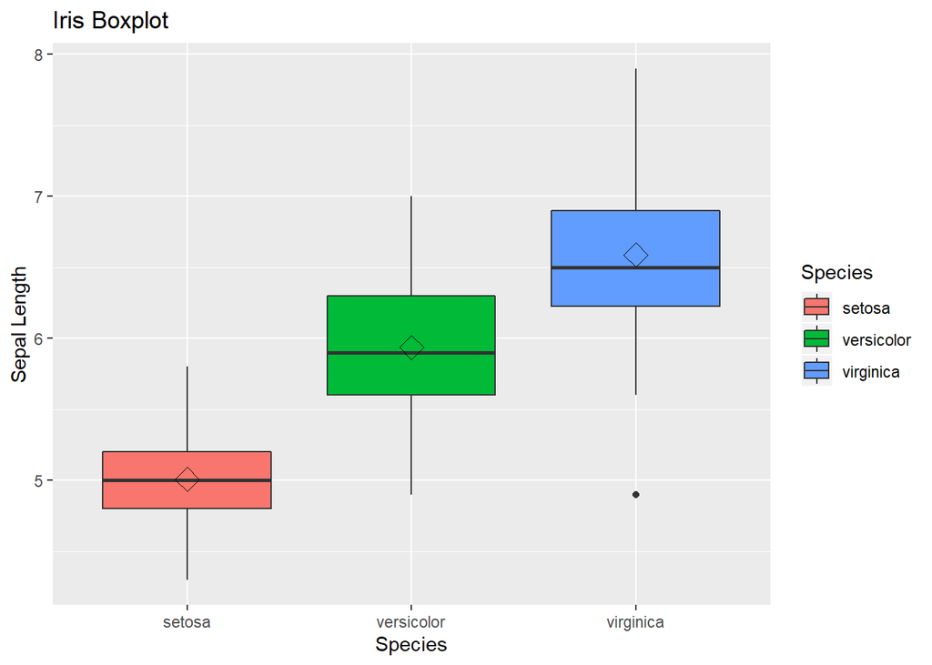

```r
box <- ggplot(data=iris, aes(x=Species, y=Sepal.Length))
box + geom_boxplot(aes(fill=Species)) +
  ylab("Sepal Length") + ggtitle("Iris Boxplot") +
  stat_summary(fun.y=mean, geom="point", shape=5, size=4)
```

# Statistical Analysis

### Data distribution

- before doing any statistical analysis, you need to know the distribution of the data

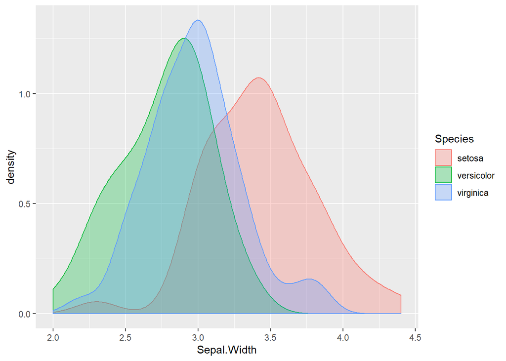

```r
ggplot(iris, aes(x=Sepal.Width)) +
  geom_density(aes(group=Species, color=Species, fill=Species), alpha=0.3)
```

### t test

- for two species

```r
setosa <- iris[iris$Species == "setosa", ]
versicolor <- iris[iris$Species == "versicolor", ]
t.test(x = setosa$Petal.Length, y = versicolor$Petal.Length)
```

```
##
##  Welch Two Sample t-test
##
## data:  setosa$Petal.Length and versicolor$Petal.Length
## t = -39.493, df = 62.14, p-value < 2.2e-16
## alternative hypothesis: true difference in means is not equal to 0
## 95 percent confidence interval:
##  -2.939618 -2.656382
## sample estimates:
## mean of x mean of y
##     1.462     4.260
```

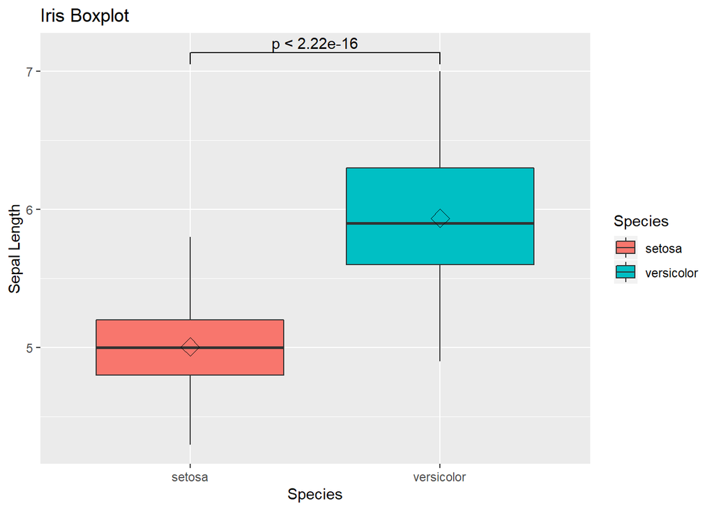

```r
TwoSpecies <- rbind(setosa, versicolor)
ggplot(data=TwoSpecies, aes(x=Species, y=Sepal.Length))+
  geom_boxplot(aes(fill=Species)) +
  ylab("Sepal Length") + ggtitle("Iris Boxplot") +
  stat_summary(fun.y=mean, geom="point", shape=5, size=4) +
  geom_signif(comparisons = list(c("setosa", "versicolor")), test=t.test)
```

- geom-signif is a very convenient function to annotate your boxplot with the statistical analysis

### Anova

```r
aov <- aov(formula = Sepal.Width ~ Species, data = iris)
summary(object = aov)
```

```
##              Df Sum Sq Mean Sq F value Pr(>F)
## Species       2  11.35   5.672   49.16 <2e-16 ***
## Residuals   147  16.96   0.115
## ---
## Signif. codes:  0 '***' 0.001 '**' 0.01 '*' 0.05 '.' 0.1 ' ' 1
```

```r
TukeyHSD(aov)
```

```
##   Tukey multiple comparisons of means
##     95% family-wise confidence level
##
## Fit: aov(formula = Sepal.Width ~ Species, data = iris)
##
## $Species
##                        diff         lwr        upr     p adj
## versicolor-setosa    -0.658 -0.81885528 -0.4971447 0.0000000
## virginica-setosa     -0.454 -0.61485528 -0.2931447 0.0000000
## virginica-versicolor  0.204  0.04314472  0.3648553 0.0087802
```

### Pairwise t-test

```r
pairwise.t.test(iris$Sepal.Width, iris$Species,
                p.adj="bonferroni", paired=FALSE)
```

```
##
##  Pairwise comparisons using t tests with pooled SD
##
## data:  iris$Sepal.Width and iris$Species
##
##            setosa  versicolor
## versicolor < 2e-16 -
## virginica  1.4e-09 0.0094
##
## P value adjustment method: bonferroni
```

# Unsupervised learning

### Clustering

#### Hierarchical clustering

```r
d <- dist(iris[, 1:4])
hcl <- hclust(d)
hcl
```

```
##
## Call:
## hclust(d = d)
##
## Cluster method   : complete
## Distance         : euclidean
## Number of objects: 150
```

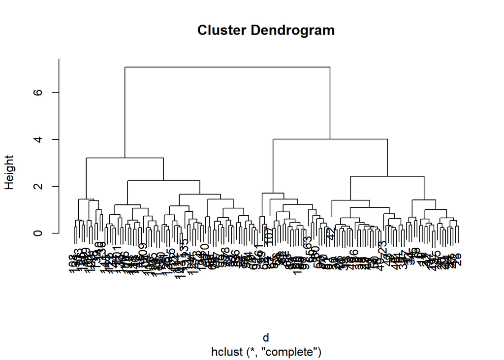

```r
plot(hcl)
```

#### Heatmap

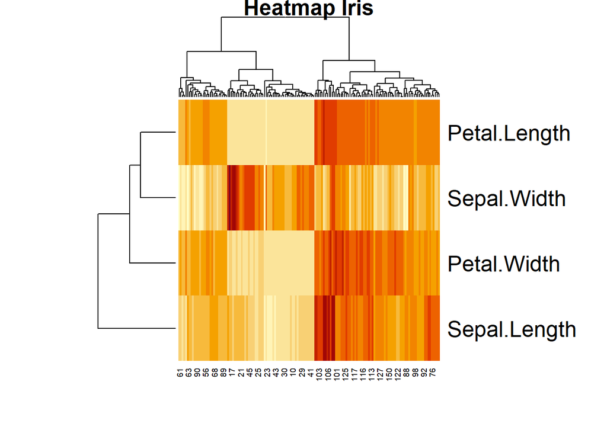

```r
X = as.matrix(iris[,-5])
heatmap(t(X), hclustfun = hclust, main = "Heatmap Iris")
```

### Dimensionality reduction

#### Visualize all 3 species and all 4 features:

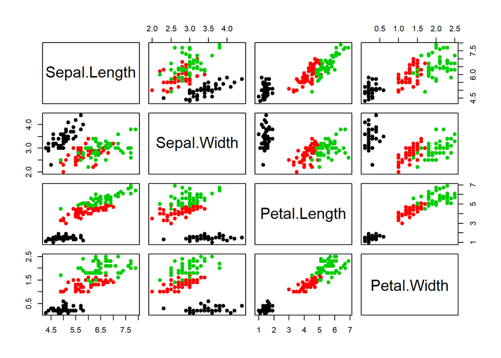

```r
pairs(iris[, -5], col = iris[, 5], pch = 19)
```

#### Principal component analysis

```r
library(ggfortify)
irispca <- prcomp(iris[, -5])
summary(irispca)
```

```
## Importance of components:
##                           PC1     PC2    PC3     PC4
## Standard deviation     2.0563 0.49262 0.2797 0.15439
## Proportion of Variance 0.9246 0.05307 0.0171 0.00521
## Cumulative Proportion  0.9246 0.97769 0.9948 1.00000
```

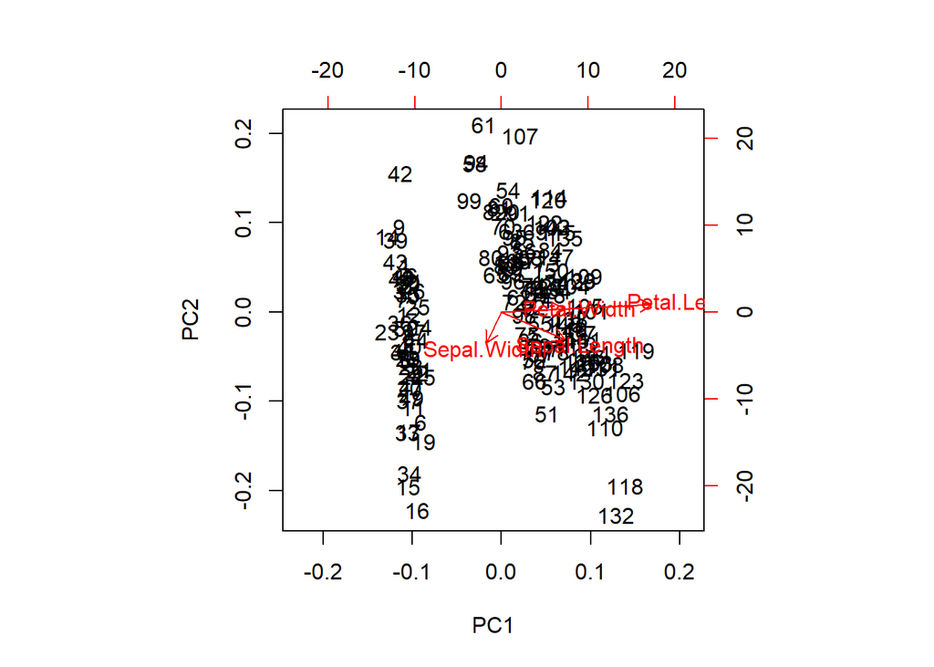

```r
biplot(irispca)
```

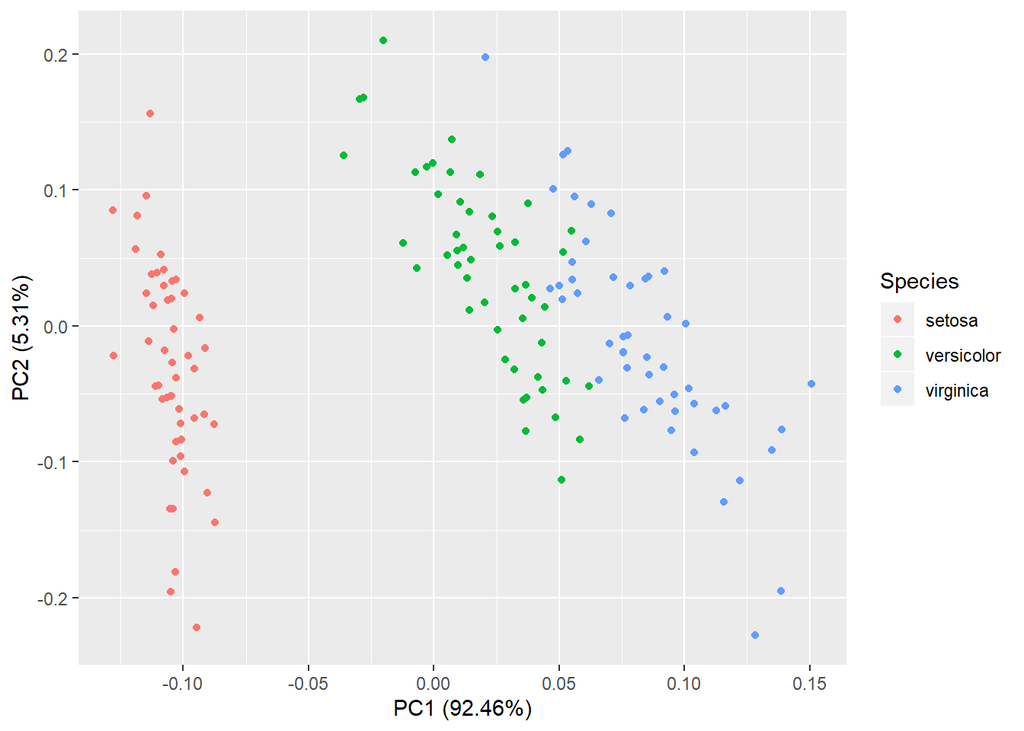

```r
autoplot(irispca, data = iris, colour = 'Species')
```